# P4

Luis Domínguez

2024-03-20

1. Realiza una gráfica con los primeros 400 valores de los siguientes procesos estocásticos.
2. Grafica la función de autocorrelación de los procesos estimada por R (usa la función acf(X)).
3. Grafica la función de autocorrelación parcial de los procesos estimada por R (usa la función pacf(X)).

Para los incisos a) y b).

1. Calcula de manera analítica, en tu cuaderno, la función de autocorrelación de los procesos dados, para los primeros 5 periodos: $\rho_0$, $\rho_1$,$\rho_2$, $\rho_3$ y $\rho_4$.
2. Compara estos valores que calculaste analíticamente con los estimados por R con la función acf.

Para los incisos c) y d)

1. Calcula la función de autocorrelación parcial de los procesos dados, para los primeros 5 periodos: $\varphi_1$,$\varphi_2$,$\varphi_3$,$\varphi_4$,$\varphi_5$ usando modelos de regresión lineal en R, como se hizo en clase.
2. Compara estos valores que calculaste con los estimados por R con la función pacf.
1. $X_t = 0.4W_{t−1} + W_t$

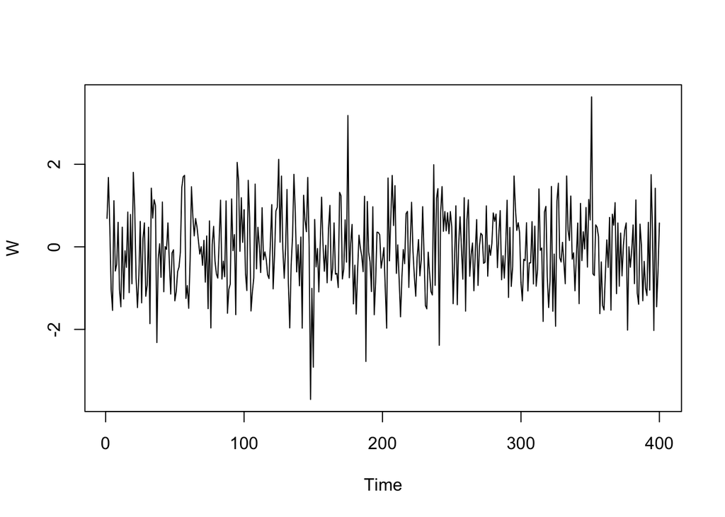

```r
n<-400
W<-rnorm(n)
X<-numeric(n)

for (t in 2:n)
  X[t]<-0.4*W[t-1]+W[t]

ts.plot(W)
```

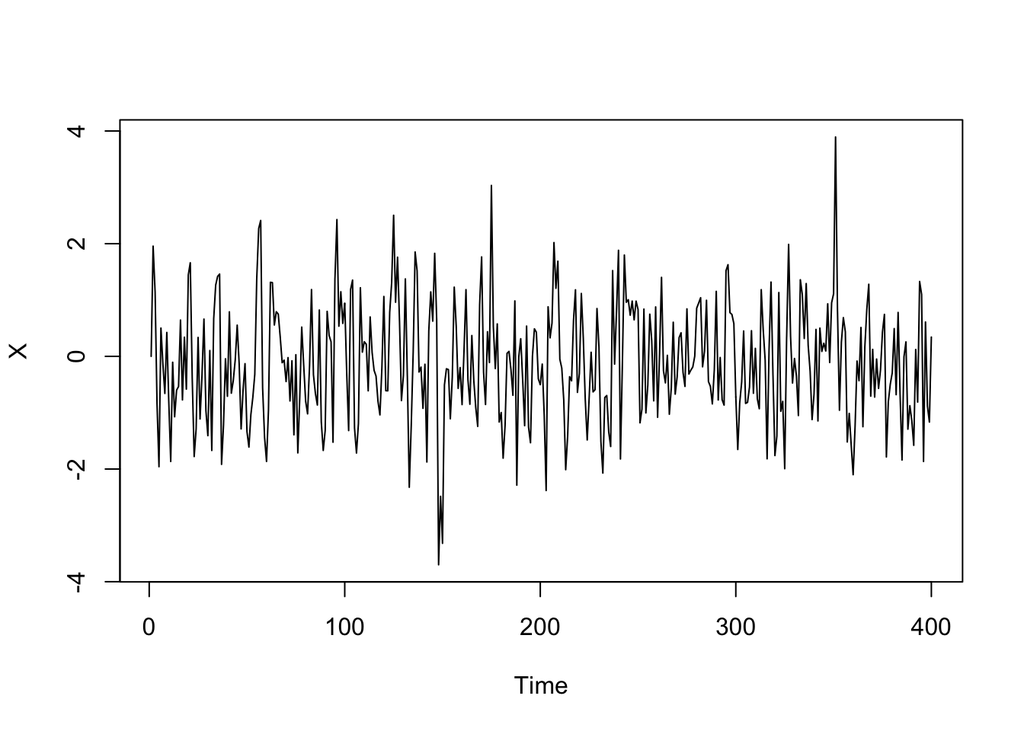

```r
ts.plot(X)
```

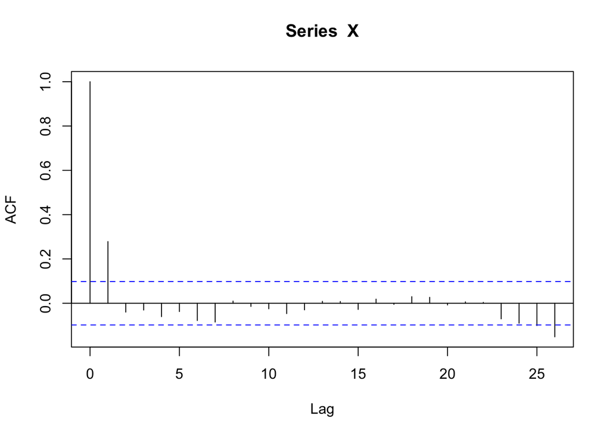

```r
acfx<-acf(X)
```

```r
acfx
```

```
##
## Autocorrelations of series 'X', by lag
##
##      0      1      2      3      4      5      6      7      8      9     10
##  1.000  0.278 -0.040 -0.031 -0.060 -0.038 -0.078 -0.085  0.010 -0.014 -0.025
##     11     12     13     14     15     16     17     18     19     20     21
## -0.047 -0.030  0.009  0.008 -0.028  0.019 -0.005  0.030  0.027 -0.008  0.006
##     22     23     24     25     26
##  0.004 -0.070 -0.090 -0.101 -0.152
```

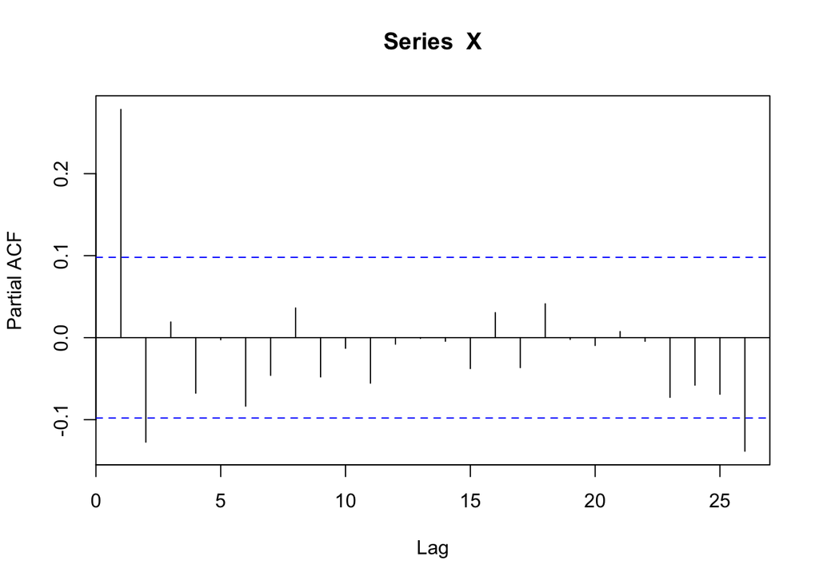

```r
pacfx<-pacf(X)
```

```r
pacfx
```

```
##
## Partial autocorrelations of series 'X', by lag
##
##      1      2      3      4      5      6      7      8      9     10     11
##  0.278 -0.127  0.019 -0.068 -0.003 -0.084 -0.046  0.036 -0.048 -0.013 -0.055
##     12     13     14     15     16     17     18     19     20     21     22
## -0.008 -0.001 -0.004 -0.038  0.030 -0.037  0.041 -0.002 -0.009  0.007 -0.004
##     23     24     25     26
## -0.073 -0.058 -0.069 -0.138
```

2. $X_t = 0.3W_{t−2} − 0.5W_{t−1} + W_t$

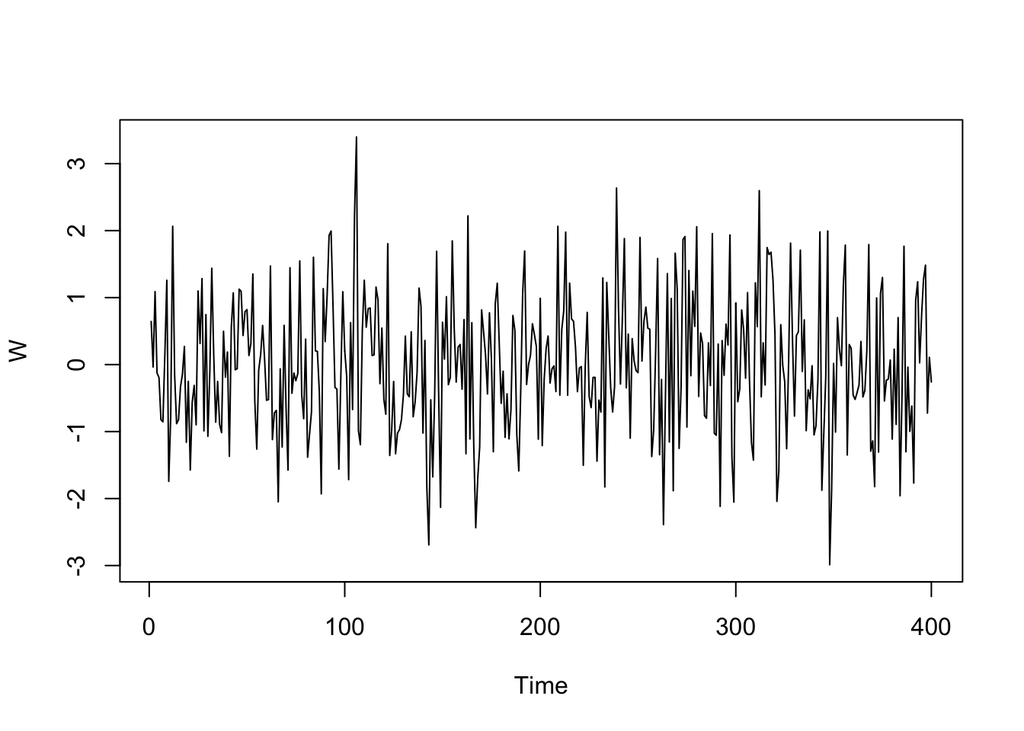

```r
n<-400
W<-rnorm(n)
X<-numeric(n)

for (t in 3:n)
  X[t]<-0.3*W[t-2]-0.5*W[t-1]+W[t]

ts.plot(W)
```

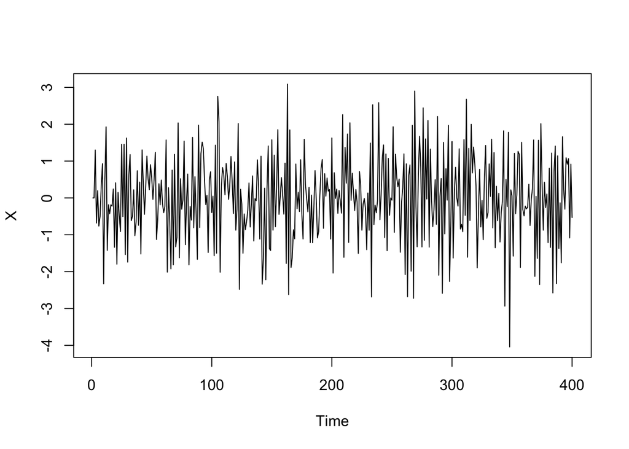

```r
ts.plot(X)
```

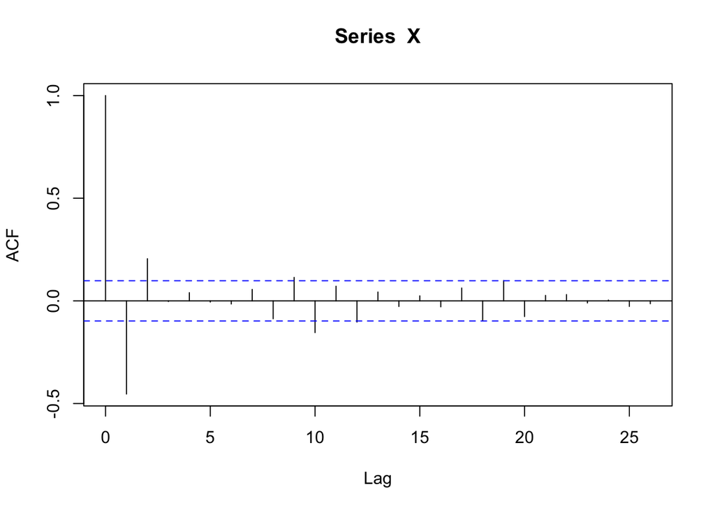

```r
acfx<-acf(X)
```

```r
acfx
```

```
##
## Autocorrelations of series 'X', by lag
##
##      0      1      2      3      4      5      6      7      8      9     10
##  1.000 -0.454  0.205 -0.003  0.040 -0.006 -0.015  0.056 -0.087  0.114 -0.154
##     11     12     13     14     15     16     17     18     19     20     21
##  0.071 -0.103  0.043 -0.027  0.024 -0.029  0.063 -0.098  0.099 -0.076  0.027
##     22     23     24     25     26
##  0.031 -0.010  0.004 -0.027 -0.014
```

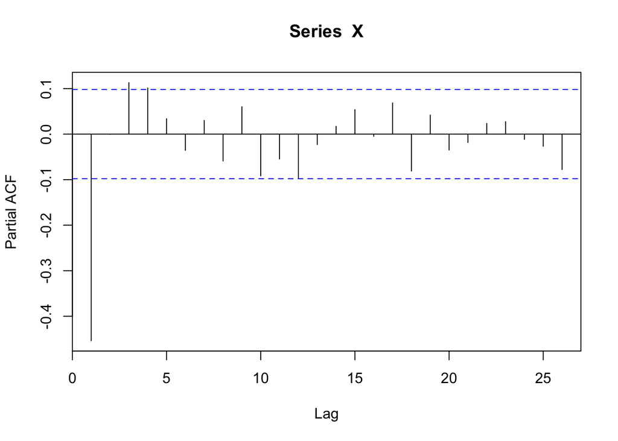

```r
pacfx<-pacf(X)
```

```r
pacfx
```

```
##
## Partial autocorrelations of series 'X', by lag
##
##      1      2      3      4      5      6      7      8      9     10     11
## -0.454 -0.001  0.113  0.101  0.034 -0.036  0.030 -0.059  0.060 -0.092 -0.055
##     12     13     14     15     16     17     18     19     20     21     22
## -0.097 -0.023  0.017  0.054 -0.005  0.068 -0.081  0.042 -0.035 -0.018  0.024
##     23     24     25     26
##  0.027 -0.011 -0.027 -0.078
```

3. $X_t = 0.7X_{t−1} + W_t$ con $X_1 = 0$ con $X_2 = 0$

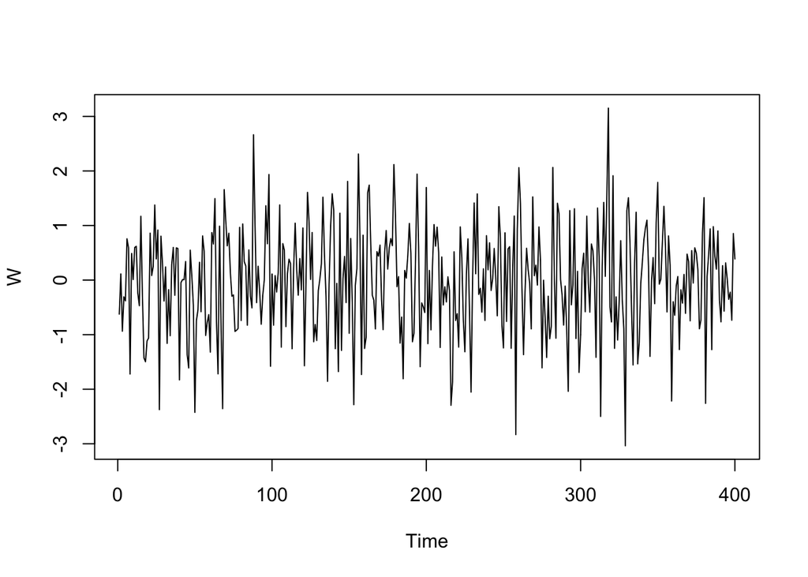

```r
n<-400
W<-rnorm(n)
X<-numeric(n)
X[1]<-0
X[2]<-0

for (t in 2:n)
  X[t]<-0.7*X[t-1]+W[t]

ts.plot(W)
```

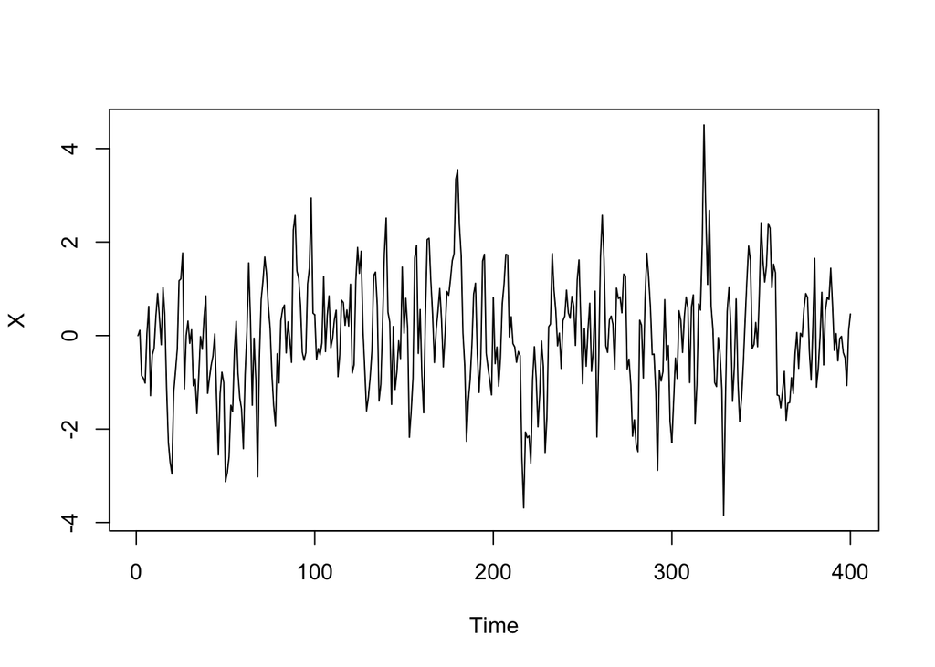

```r
ts.plot(X)
```

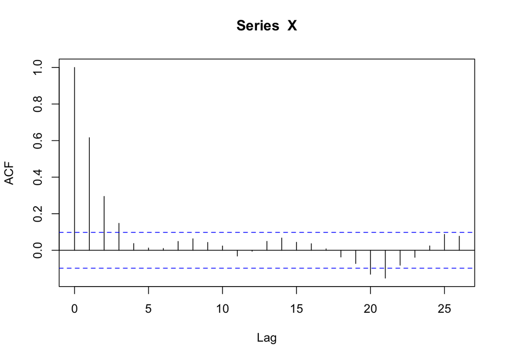

```r
acfx<-acf(X)
```

```r
acfx
```

```
##
## Autocorrelations of series 'X', by lag
##
##      0      1      2      3      4      5      6      7      8      9     10
##  1.000  0.616  0.295  0.148  0.037  0.013  0.010  0.048  0.063  0.043  0.024
##     11     12     13     14     15     16     17     18     19     20     21
## -0.031 -0.005  0.049  0.067  0.044  0.036  0.008 -0.037 -0.073 -0.131 -0.152
##     22     23     24     25     26
## -0.082 -0.039  0.024  0.087  0.077
```

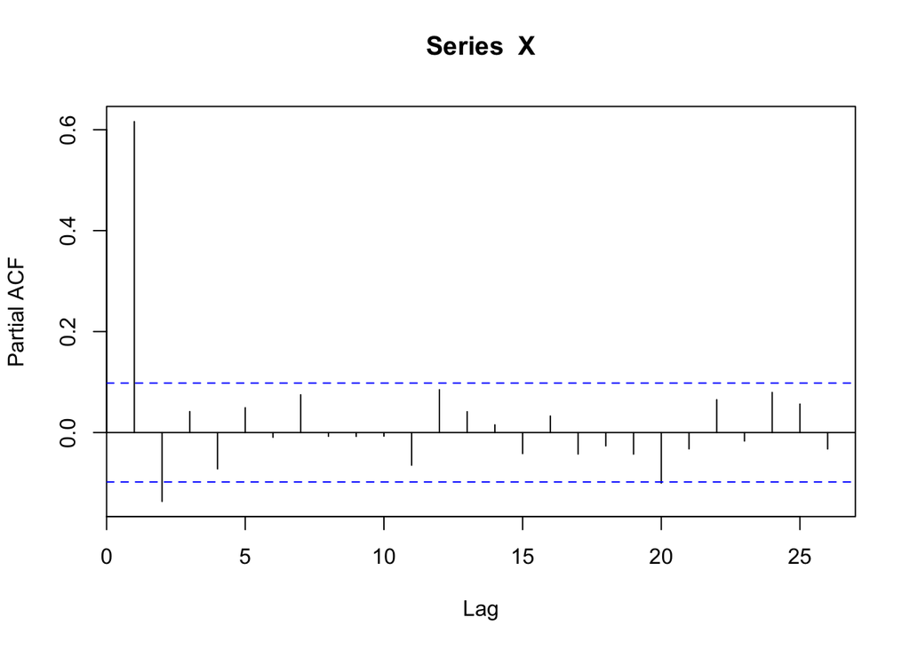

```r
pacfx<-pacf(X)
```

```r
pacfx
```

```
##
## Partial autocorrelations of series 'X', by lag
##
##      1      2      3      4      5      6      7      8      9     10     11
##  0.616 -0.137  0.041 -0.072  0.049 -0.009  0.075 -0.008 -0.008 -0.007 -0.065
##     12     13     14     15     16     17     18     19     20     21     22
##  0.085  0.041  0.015 -0.042  0.033 -0.043 -0.026 -0.043 -0.100 -0.032  0.065
##     23     24     25     26
## -0.017  0.079  0.056 -0.033
```

```r
X1<-numeric(n)
for (t in 2:n)
  X1[t]<-X[t-1]

X2<-numeric(n)
for (t in 3:n)
  X2[t]<-X[t-2]

X3<-numeric(n)
for (t in 4:n)
  X3[t]<-X[t-3]

X4<-numeric(n)
for (t in 5:n)
  X4[t]<-X[t-4]

X5<-numeric(n)
for (t in 6:n)
  X5[t]<-X[t-5]

X<-X[-c(1:6)]
X1<-X1[-c(1:6)]
X2<-X2[-c(1:6)]
X3<-X3[-c(1:6)]
X4<-X4[-c(1:6)]
X5<-X5[-c(1:6)]

modelo1<-lm(X~X1)
summary(modelo1)
```

```
##
## Call:
## lm(formula = X ~ X1)
##
## Residuals:
##     Min      1Q  Median      3Q     Max
## -3.1138 -0.7209  0.0419  0.6678  3.3322
##
## Coefficients:
##             Estimate Std. Error t value Pr(>|t|)
## (Intercept) -0.01938    0.04957  -0.391    0.696
## X1           0.61654    0.03978  15.499   <2e-16 ***
## ---
## Signif. codes:  0 '***' 0.001 '**' 0.01 '*' 0.05 '.' 0.1 ' ' 1
##
## Residual standard error: 0.9831 on 392 degrees of freedom
## Multiple R-squared:   0.38,  Adjusted R-squared:  0.3784
## F-statistic: 240.2 on 1 and 392 DF,  p-value: < 2.2e-16
```

```r
modelo2<-lm(X~X1+X2)
summary(modelo2)
```

```
##
## Call:
## lm(formula = X ~ X1 + X2)
##
## Residuals:
##     Min      1Q  Median      3Q     Max
## -3.0661 -0.7283  0.0784  0.6194  3.2471
##
## Coefficients:
##             Estimate Std. Error t value Pr(>|t|)
## (Intercept) -0.02255    0.04919  -0.459  0.64682
## X1           0.70051    0.05008  13.988  < 2e-16 ***
## X2          -0.13627    0.05004  -2.723  0.00676 **
## ---
## Signif. codes:  0 '***' 0.001 '**' 0.01 '*' 0.05 '.' 0.1 ' ' 1
##
## Residual standard error: 0.9752 on 391 degrees of freedom
## Multiple R-squared:  0.3915, Adjusted R-squared:  0.3884
## F-statistic: 125.8 on 2 and 391 DF,  p-value: < 2.2e-16
```

```r
modelo3<-lm(X~X1+X2+X3)
summary(modelo3)
```

```
##
## Call:
## lm(formula = X ~ X1 + X2 + X3)
##
## Residuals:
##     Min      1Q  Median      3Q     Max
## -3.0701 -0.7224  0.0894  0.6465  3.2226
##
## Coefficients:
##             Estimate Std. Error t value Pr(>|t|)
## (Intercept) -0.02156    0.04922  -0.438  0.66158
## X1           0.70621    0.05057  13.966  < 2e-16 ***
## X2          -0.16568    0.06134  -2.701  0.00722 **
## X3           0.04198    0.05061   0.830  0.40733
## ---
## Signif. codes:  0 '***' 0.001 '**' 0.01 '*' 0.05 '.' 0.1 ' ' 1
##
## Residual standard error: 0.9755 on 390 degrees of freedom
## Multiple R-squared:  0.3926, Adjusted R-squared:  0.3879
## F-statistic: 84.02 on 3 and 390 DF,  p-value: < 2.2e-16
```

```r
modelo4<-lm(X~X1+X2+X3+X4)
summary(modelo4)
```

```
##
## Call:
## lm(formula = X ~ X1 + X2 + X3 + X4)
##
## Residuals:
##      Min       1Q   Median       3Q      Max
## -3.14740 -0.73211  0.08644  0.63517  3.11185
##
## Coefficients:
##             Estimate Std. Error t value Pr(>|t|)
## (Intercept) -0.02335    0.04917  -0.475  0.63516
## X1           0.70923    0.05054  14.033  < 2e-16 ***
## X2          -0.17776    0.06182  -2.875  0.00426 **
## X3           0.09384    0.06192   1.516  0.13043
## X4          -0.07333    0.05058  -1.450  0.14791
## ---
## Signif. codes:  0 '***' 0.001 '**' 0.01 '*' 0.05 '.' 0.1 ' ' 1
##
## Residual standard error: 0.9742 on 389 degrees of freedom
## Multiple R-squared:  0.3958, Adjusted R-squared:  0.3896
## F-statistic: 63.72 on 4 and 389 DF,  p-value: < 2.2e-16
```

```r
modelo5<-lm(X~X1+X2+X3+X4+X5)
summary(modelo5)
```

```
##
## Call:
## lm(formula = X ~ X1 + X2 + X3 + X4 + X5)
##
## Residuals:
##     Min      1Q  Median      3Q     Max
## -3.1343 -0.7139  0.0885  0.6493  3.1563
##
## Coefficients:
##             Estimate Std. Error t value Pr(>|t|)
## (Intercept) -0.02217    0.04918  -0.451  0.65242
## X1           0.71278    0.05067  14.066  < 2e-16 ***
## X2          -0.18227    0.06200  -2.940  0.00348 **
## X3           0.10260    0.06257   1.640  0.10187
## X4          -0.10839    0.06207  -1.746  0.08157 .
## X5           0.04939    0.05069   0.974  0.33043
## ---
## Signif. codes:  0 '***' 0.001 '**' 0.01 '*' 0.05 '.' 0.1 ' ' 1
##
## Residual standard error: 0.9742 on 388 degrees of freedom
## Multiple R-squared:  0.3973, Adjusted R-squared:  0.3895
## F-statistic: 51.16 on 5 and 388 DF,  p-value: < 2.2e-16
```

4. $X_t = 0.2X_{t−1} + 0.3X_{t−2} + W_t$ con $X_1 = 1$ con $X_2 = 0$

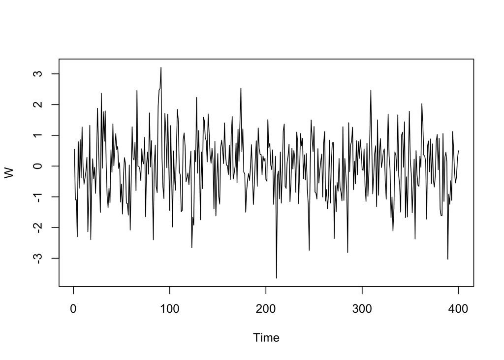

```r
n<-400
W<-rnorm(n)
X<-numeric(n)
X[1]<-1
X[2]<-0

for (t in 3:n)
  X[t]<-0.2*X[t-1]+0.3*X[t-2]+W[t]

ts.plot(W)
```

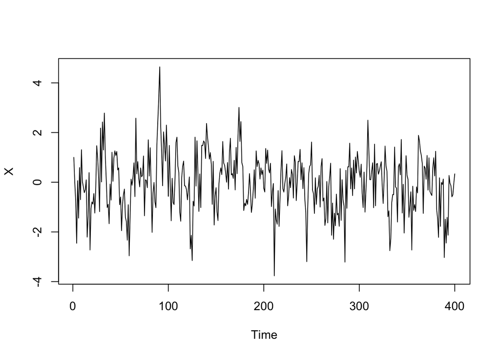

```r
ts.plot(X)
```

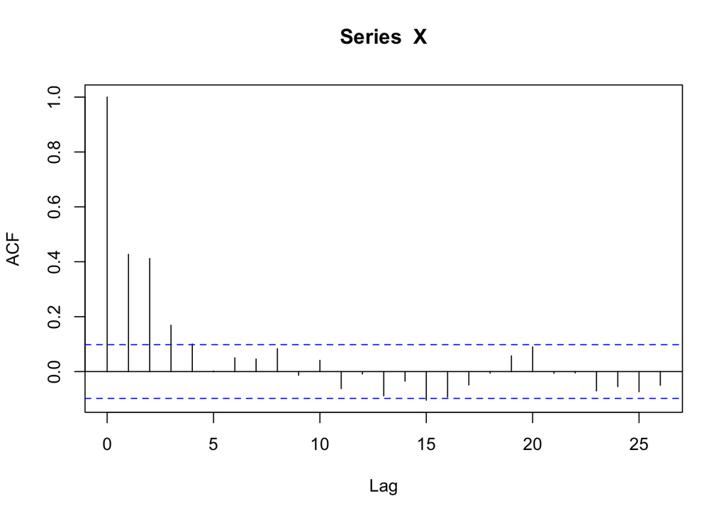

```r
acfx<-acf(X)
```

```r
acfx
```

```
##
## Autocorrelations of series 'X', by lag
##
##      0      1      2      3      4      5      6      7      8      9     10
##  1.000  0.427  0.412  0.169  0.101  0.002  0.050  0.046  0.083 -0.013  0.041
##     11     12     13     14     15     16     17     18     19     20     21
## -0.062 -0.009 -0.089 -0.035 -0.104 -0.093 -0.049 -0.006  0.057  0.090 -0.006
##     22     23     24     25     26
## -0.005 -0.071 -0.055 -0.073 -0.050
```

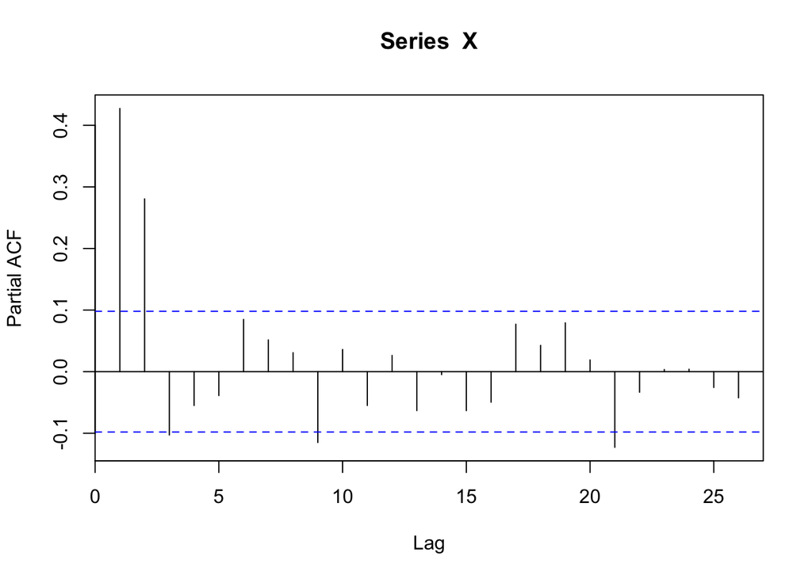

```r
pacfx<-pacf(X)
```

```r
pacfx
```

```
##
## Partial autocorrelations of series 'X', by lag
##
##      1      2      3      4      5      6      7      8      9     10     11
##  0.427  0.280 -0.103 -0.055 -0.039  0.085  0.052  0.031 -0.115  0.036 -0.055
##     12     13     14     15     16     17     18     19     20     21     22
##  0.026 -0.063 -0.005 -0.063 -0.050  0.077  0.043  0.079  0.019 -0.123 -0.033
##     23     24     25     26
##  0.004  0.004 -0.026 -0.042
```

```r
X1<-numeric(n)
for (t in 2:n)
  X1[t]<-X[t-1]

X2<-numeric(n)
for (t in 3:n)
  X2[t]<-X[t-2]

X3<-numeric(n)
for (t in 4:n)
  X3[t]<-X[t-3]

X4<-numeric(n)
for (t in 5:n)
  X4[t]<-X[t-4]

X5<-numeric(n)
for (t in 6:n)
  X5[t]<-X[t-5]

X<-X[-c(1:6)]
X1<-X1[-c(1:6)]
X2<-X2[-c(1:6)]
X3<-X3[-c(1:6)]
X4<-X4[-c(1:6)]
X5<-X5[-c(1:6)]

modelo1<-lm(X~X1)
summary(modelo1)
```

```
##
## Call:
## lm(formula = X ~ X1)
##
## Residuals:
##     Min      1Q  Median      3Q     Max
## -3.7399 -0.6802  0.0631  0.6586  3.1528
##
## Coefficients:
##              Estimate Std. Error t value Pr(>|t|)
## (Intercept) -0.004996   0.053616  -0.093    0.926
## X1           0.430356   0.045493   9.460   <2e-16 ***
## ---
## Signif. codes:  0 '***' 0.001 '**' 0.01 '*' 0.05 '.' 0.1 ' ' 1
##
## Residual standard error: 1.064 on 392 degrees of freedom
## Multiple R-squared:  0.1859, Adjusted R-squared:  0.1838
## F-statistic: 89.49 on 1 and 392 DF,  p-value: < 2.2e-16
```

```r
modelo2<-lm(X~X1+X2)
summary(modelo2)
```

```
##
## Call:
## lm(formula = X ~ X1 + X2)
##
## Residuals:
##     Min      1Q  Median      3Q     Max
## -3.6450 -0.6115  0.0037  0.6851  2.8786
##
## Coefficients:
##              Estimate Std. Error t value Pr(>|t|)
## (Intercept) -0.002412   0.051537  -0.047    0.963
## X1           0.310114   0.048437   6.402 4.39e-10 ***
## X2           0.279522   0.048437   5.771 1.61e-08 ***
## ---
## Signif. codes:  0 '***' 0.001 '**' 0.01 '*' 0.05 '.' 0.1 ' ' 1
##
## Residual standard error: 1.023 on 391 degrees of freedom
## Multiple R-squared:  0.2498, Adjusted R-squared:  0.2459
## F-statistic: 65.08 on 2 and 391 DF,  p-value: < 2.2e-16
```

```r
modelo3<-lm(X~X1+X2+X3)
summary(modelo3)
```

```
##
## Call:
## lm(formula = X ~ X1 + X2 + X3)
##
## Residuals:
##     Min      1Q  Median      3Q     Max
## -3.7295 -0.6353  0.0149  0.6946  2.8555
##
## Coefficients:
##              Estimate Std. Error t value Pr(>|t|)
## (Intercept) -0.003574   0.051340  -0.070   0.9445
## X1           0.339127   0.050355   6.735 5.90e-11 ***
## X2           0.310335   0.050618   6.131 2.14e-09 ***
## X3          -0.100732   0.050027  -2.014   0.0447 *
## ---
## Signif. codes:  0 '***' 0.001 '**' 0.01 '*' 0.05 '.' 0.1 ' ' 1
##
## Residual standard error: 1.019 on 390 degrees of freedom
## Multiple R-squared:  0.2575, Adjusted R-squared:  0.2518
## F-statistic: 45.08 on 3 and 390 DF,  p-value: < 2.2e-16
```

```r
modelo4<-lm(X~X1+X2+X3+X4)
summary(modelo4)
```

```
##
## Call:
## lm(formula = X ~ X1 + X2 + X3 + X4)
##
## Residuals:
##     Min      1Q  Median      3Q     Max
## -3.6575 -0.6545 -0.0142  0.6737  2.7396
##
## Coefficients:
##              Estimate Std. Error t value Pr(>|t|)
## (Intercept) -0.004238   0.051317  -0.083    0.934
## X1           0.333106   0.050587   6.585 1.48e-10 ***
## X2           0.329282   0.053077   6.204 1.41e-09 ***
## X3          -0.080878   0.052754  -1.533    0.126
## X4          -0.059337   0.050267  -1.180    0.239
## ---
## Signif. codes:  0 '***' 0.001 '**' 0.01 '*' 0.05 '.' 0.1 ' ' 1
##
## Residual standard error: 1.018 on 389 degrees of freedom
## Multiple R-squared:  0.2601, Adjusted R-squared:  0.2525
## F-statistic: 34.19 on 4 and 389 DF,  p-value: < 2.2e-16
```

```r
modelo5<-lm(X~X1+X2+X3+X4+X5)
summary(modelo5)
```

```
##
## Call:
## lm(formula = X ~ X1 + X2 + X3 + X4 + X5)
##
## Residuals:
##     Min      1Q  Median      3Q     Max
## -3.6415 -0.6613 -0.0371  0.6937  2.7191
##
## Coefficients:
##              Estimate Std. Error t value Pr(>|t|)
## (Intercept) -0.004593   0.051349  -0.089    0.929
## X1           0.330789   0.050714   6.523 2.16e-10 ***
## X2           0.326386   0.053253   6.129 2.18e-09 ***
## X3          -0.068492   0.055387  -1.237    0.217
## X4          -0.047132   0.052943  -0.890    0.374
## X5          -0.037160   0.050328  -0.738    0.461
## ---
## Signif. codes:  0 '***' 0.001 '**' 0.01 '*' 0.05 '.' 0.1 ' ' 1
##
## Residual standard error: 1.019 on 388 degrees of freedom
## Multiple R-squared:  0.2612, Adjusted R-squared:  0.2516
## F-statistic: 27.43 on 5 and 388 DF,  p-value: < 2.2e-16
```